# Temperatura histórica en C.A.B.A. - Solucion del TP

Trabajos Practicos - Laboratorio de Datos

Ezequiel Remus

19 de Agosto de 2021

# Este notebook

En este notebook el objetivo es que ustedes puedan emplear lo visto en el notebook *Nociones básicas de estadística descriptiva* para caracterizar la evolución de la temperatura mensual en la C.A.B.A.

Proponemos una serie de preguntas *guía* a responder usando las herramientas que presentadas en el notebook de estadística descriptiva. Sientan la libertad de hacer nuevas preguntas y explorar el dataset libremente.

# El dataset

El dataset que usaremos puede descargarse (además del repositorio) de la página del gobierno de la ciudad en formato csv: https://data.buenosaires.gob.ar/dataset/registro-temperatura-ciudad. También lo pueden encontrar en el GitHub de la materia ya descargado.

Carguemoslo:

```r
datos = read.csv('historico_temperaturas.csv')
```

- Visualicen las primeras filas usando la función `head`

```r
head(datos)
```

|  | aÃ.o | mes | mÃ.xima | mÃ.nima | media |
| --- | --- | --- | --- | --- | --- |
| 1 | 1991 | Enero | 28.4 | 19.8 | 24.10 |
| 2 | 1991 | Febrero | 27.8 | 17.8 | 22.80 |
| 3 | 1991 | Marzo | 27.6 | 18.4 | 23.00 |
| 4 | 1991 | Abril | 22.4 | 13.6 | 18.00 |
| 5 | 1991 | Mayo | 20.7 | 12.2 | 16.45 |
| 6 | 1991 | Junio | 14.8 | 7.6 | 11.20 |

Dado que mes y año no están en un formato cómodo para ser procesado y graficado, necesitamos crear un string que contenga esa misma información pero en formato *YYYY-MM-DD* (año-mes-día). Hay formas de hacerlo automáticamente, pero hoy la función la van a hacer ustedes. Les dejo un boceto:

```r
# FUNCIONES
arma_fecha = function(anio,mes){

  # Primero necesitamos convertir el mes en palabras a número con dos dígitos.
  # Lo hacemos con un diccionario y la función match
  diccionario = c('Enero'='01', 'Febrero'='02', 'Marzo'='03', 'Abril'='04',
                  'Mayo'='05', 'Junio'='06','Julio'='07', 'Agosto'='08',
                  'Septiembre'='09','Octubre'='10','Noviembre'='11','Diciembre'='12')

  mes_numerico = diccionario[match(mes,names(diccionario))]
  # Fijamos el día siempre en el primero del més
  fechas = paste(anio, mes_numerico, '01',sep='-')
  # Lo convertimos a un formato de fecha
  fechas = as.Date(fechas)

  return(fechas)
}

# VARIABLES
month = datos$mes
anio = datos$aÃ.o

# EJECUCIÓN
datos$fecha = arma_fecha(anio,month)
# print(datos$fecha)
```

# Preguntas

#### ¿Qué puede decir de la evolución de la temperatura a lo largo del tiempo?

Realice un gráfico que muestre la temperatura media en función de la fecha. *Sugerencia: agregando en* `plot(x,y)` *la opción `type='l'` obtenemos un gráfico de lineas:* `plot(x,y,type='l')`.

- Solución:

Lo que tenemos que hacer es, tomar una variable `temp_media` en la cual guardaremos todos los valores de las temperaturas medias. Luego, tomamos con la funcion que hicimos para tomar las fechas, y agarramos los valores numericos de estas, luego, graficamos en $y$ la temperatura y en $x$ la fecha.

```r
temp_media = datos$media
fechas = datos$fecha

plot(fechas, temp_media, type='l', lwd=0.5)
grid()
```

[output not shown]

#### ¿Qué puede decir de la evolución de la mínima y la máxima en función del tiempo?

Realice un gráfico que muestre la evolución de las tres temperaturas (mínima, media y máxima) a la vez, con lineas y usando diferentes colores. *Los colores los indicamos usando la opción* `col` _ en la función `plot`. _Para agregar lineas usamos la función `lines`.

```r
temp_min = datos$mÃ.nima
temp_max = datos$mÃ.xima
temp_media = datos$media
fechas = datos$fecha

plot(fechas, temp_min, type = "l", col="blue", main="Temperaturas Minimas")
plot(fechas, temp_media, type = "l", col="green", main="Temperaturas Medias")
plot(fechas, temp_max, type = "l", col="red", main="Temperaturas Maximas")
```

[output not shown]

#### ¿En qué año y mes se registró la temperatura máxima? ¿Y la mínima?

Detecte, año, mes y fecha y repita el gráfico anterior, agregando un punto rojo y uno azul en la posición de la temperatura máxima y mínima. *Para agregar puntos a un gráfico, puede usar la función* `points` *, similar a* `lines` *. Para ubicar las posiciones donde ocurre el máximo y el mínimo de un vector aproveche las funciones* `which.max` *y* `which.min`.

```r
#-----------------------------------------
# MAXIMO Y MINIMO DE TEMPERATURAS MINIMAS
#-----------------------------------------

rango_temperatura_minima = range(datos$mÃ.nima)

d_min_min = datos$mÃ.nima == rango_temperatura_minima[1]
fecha_min_min = datos$fecha[d_min_min == TRUE]
d_min_max = datos$mÃ.nima == rango_temperatura_minima[2]
fecha_min_max = datos$fecha[d_min_max == TRUE]


plot(fechas, temp_min, type = "l", main = "Temperaturas minimas en el tiempo")
points(x = fecha_min_min, y = rango_temperatura_minima[1], col="blue")
points(x = fecha_min_max, y = rango_temperatura_minima[2], col="red")
```

[output not shown]

```r
#-----------------------------------------
# MAXIMO Y MINIMO DE TEMPERATURAS MINIMAS
#-----------------------------------------

rango_temperatura_minima = range(datos$mÃ.nima)

d_min_min = datos$mÃ.nima == rango_temperatura_minima[1]
fecha_min_min = datos$fecha[d_min_min == TRUE]
d_min_max = datos$mÃ.nima == rango_temperatura_minima[2]
fecha_min_max = datos$fecha[d_min_max == TRUE]


plot(fechas, temp_min, type = "l", main = "Temperaturas minimas en el tiempo")
points(x = fecha_min_min, y = rango_temperatura_minima[1], col="blue")
```

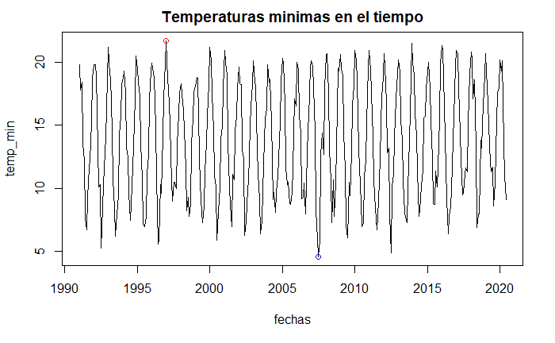

```r
points(x = fecha_min_max, y = rango_temperatura_minima[2], col="red")
```

```r
#-----------------------------------------
# MAXIMO Y MINIMO DE TEMPERATURAS MEDIAS
#-----------------------------------------

rango_temperatura_media = range(datos$media)

d_med_min = datos$media == rango_temperatura_media[1]
fecha_med_min = datos$fecha[d_med_min == TRUE]

d_med_max = datos$media == rango_temperatura_media[2]
fecha_med_max = datos$fecha[d_med_max == TRUE]
#Notemos que en este caso, se repiten los valores maximos de temperatura en varias ocaciones
#como hago? -> es un vector!

plot(fechas, temp_media, type = "l", main = "MAXIMO Y MINIMO DE TEMPERATURAS MEDIAS")
points(x = fecha_med_min, y = rango_temperatura_media[1], col="blue")
```

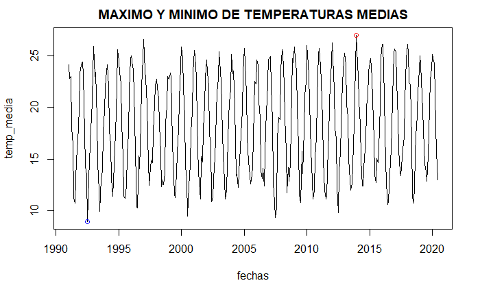

```r
points(x = fecha_med_max, y = rango_temperatura_media[2], col="red")
```

#### ¿En torno a que valor ronda la temperatura en C.A.B.A.?

Calcule las temperaturas promedio y mediana a lo largo de todos los años usando la temperatura media mensual. ¿Son similares en este caso? Calcule la desviación estandar de la temperatura media y los cuartiles 1ro y 3ro, y agreguelos al gráfico original de la temperatura media. *La función* `abline` *permite dibujar lineas horizontales a través de su argumento* `h`.

El promedio se calcula con la función `mean` y la mediana con la función `median`

```r
promedio = mean(temp_media)
mediana = median(temp_media)
desv_estandar = sd(temp_media)
dist_int_cuar = IQR(temp_media)

cat("Promedio: ", " ",  promedio, "\n")
cat("Mediana : ", " ", mediana, "\n")
cat("Desviación estandar : ", " ", desv_estandar, "\n")
cat("Teniendo encuanta que los cuartiles 0,25,50,75,100. Son : \n")
cat("Cuantiles : ", quantile(temp_media), "\n")
cat("Distancia Intercuartil: ", " ", dist_int_cuar, "\n")
```

[output not shown]

```r
promedio = mean(temp_media)
mediana = median(temp_media)
desv_estandar = sd(temp_media)
dist_int_cuar = IQR(temp_media)

cat("Promedio: ", " ",  promedio, "\n")
```

```
Promedio:    18.40493
```

```r
cat("Mediana : ", " ", mediana, "\n")
```

```
Mediana :    18.275
```

```r
cat("Desviación estandar : ", " ", desv_estandar, "\n")
```

```
Desviación estandar :    4.776078
```

```r
cat("Teniendo encuanta que los cuartiles 0,25,50,75,100. Son : \n")
```

```
Teniendo encuanta que los cuartiles 0,25,50,75,100. Son :
```

```r
cat("Cuantiles : ", quantile(temp_media), "\n")
```

```
Cuantiles :  8.95 14.2125 18.275 22.9 27
```

```r
cat("Distancia Intercuartil: ", " ", dist_int_cuar, "\n")
```

```
Distancia Intercuartil:    8.6875
```

#### ¿Cuál es el mes más frio del año? ¿Y el más cálido?

Calcule la temperatura media, mínima y máxima promedio para cada mes, y construya un barplot de la temperatura media separado por mes. ¿Qué meses presentan temperaturas más atípicas?

```r
tomo_fechas_mes = function(mes_string) {

  m = datos$mes == mes_string
  mes = datos$mes[m == TRUE]

  return(mes)
}




Promedio_minimas = function(meses) {
   promedio = 0
   temp = rep(0,12)

   for (i in 1:12) {
      temp = datos$mÃ.nima[datos$mes == meses[i]]
      promedio[i] = mean(temp)
   }

   return(promedio)
}

Promedio_medias = function(meses) {
   promedio = 0
   temp = rep(0,12)

   for (i in 1:12) {
      temp = datos$media[datos$mes == meses[i]]
      promedio[i] = mean(temp)
   }

   return(promedio)
}

Promedio_maximos = function(meses) {
   promedio = 0
   temp = rep(0,12)

   for (i in 1:12) {
      temp = datos$mÃ.xima[datos$mes == meses[i]]
      promedio[i] = mean(temp)
   }

   return(promedio)
}

dic_meses = c('Enero','Febrero', 'Marzo','Abril','Mayo','Junio','Julio','Agosto','Septiembre','Octubre','Noviembre','Diciembre')

#promedios = mean(tomo_temperatura("Enero"))
prom_temp_minimas_meses = Promedio_minimas(dic_meses)
prom_temp_medias_meses = Promedio_medias(dic_meses)
prom_temp_maximas_meses = Promedio_maximos(dic_meses)
cat("Promedios de temperaturas minimas por mes:\n", prom_temp_minimas_meses, "\n",
    "Promedios de temperaturas medias por mes:\n", prom_temp_medias_meses, "\n",
    "Promedios de temperaturas maximas por mes:\n", prom_temp_maximas_meses, "\n")
barplot(prom_temp_minimas_meses, main="Promedios de temperaturas minimas por mes")
```

[output not shown]

#### ¿Cuál es el mes con temperatura más variable?

Calcule la variabilidad de la temperatura de cada mes como `máxima-mínima` (llamada *amplitud térmica*) y calcule el promedio mensual y construya un boxplot para cada mes. ¿En qué mes es más variable la temperatura? ¿Y en cuál menos? ¿Observa una relación con la temperatura del mes?

#### ¿Cómo se relacionan la temperatura media y la variabilidad?

Grafique la temperatura media contra la variabilidad. ¿Observa una relación? Calcule el coeficiente de correlación entre ambas. ¿Se condice con lo que observa en el gráfico?

#### ¿Cómo cambió la temperatura a lo largo de los años?

Grafique boxplots separando la temperatura media por año, y la amplitud térmica por año. Calcule la temperatura media, mínima y máxima por año. ¿Detecta algún año especialmente frío? Grafique la temperatura media, máxima y mínima año a año. ¿Puede detectar un cambio a lo largo de los años?